# final

Gradually copy the code from the tutorial into your own jupyter notebook, run and debug until you successfully replicate the tutorial. Do not try to copy and run it all at once, it's not going to work! You need to debug as you go. Use markdown to break the notebook into sections, as in the tutorial. Finish your notebook by answering the following questions, using a combination of text and code directly in the notebook. (Terms like sources and fluxes will gradually become clear as you progress through the tutorial. You are not expected to fully understand all the details.)

```python
import numpy as np
import sep
```

# additional setup for reading the test image and displaying plots

```python
import fitsio
import matplotlib.pyplot as plt
from matplotlib import rcParams

%matplotlib inline

rcParams['figure.figsize'] = [10., 8.]
```

# read image into standard 2-d numpy array

```python
data = fitsio.read("data.fits")
```

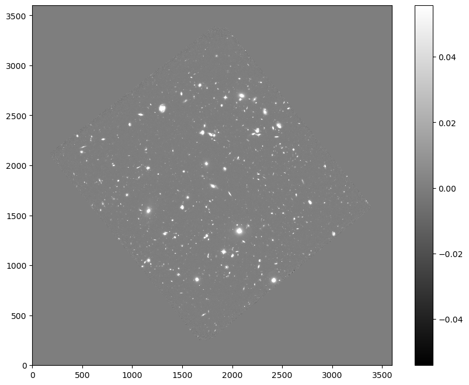

```python
m, s = np.mean(data), np.std(data)
plt.imshow(data, interpolation='nearest', cmap='gray', vmin=m-s, vmax=m+s, origin='lower')
plt.colorbar();
```

# measure a spatially varying background on the image

```python
bkg = sep.Background(data)
```

# get a "global" mean and noise of the image background:

```python
print(bkg.globalback)
print(bkg.globalrms)
```

```
0.0
0.0005398219218477607
```

# evaluate background as 2-d array, same size as original image

```python
bkg_image = bkg.back()
```

# bkg_image = np.array(bkg) # equivalent to above

# show the background

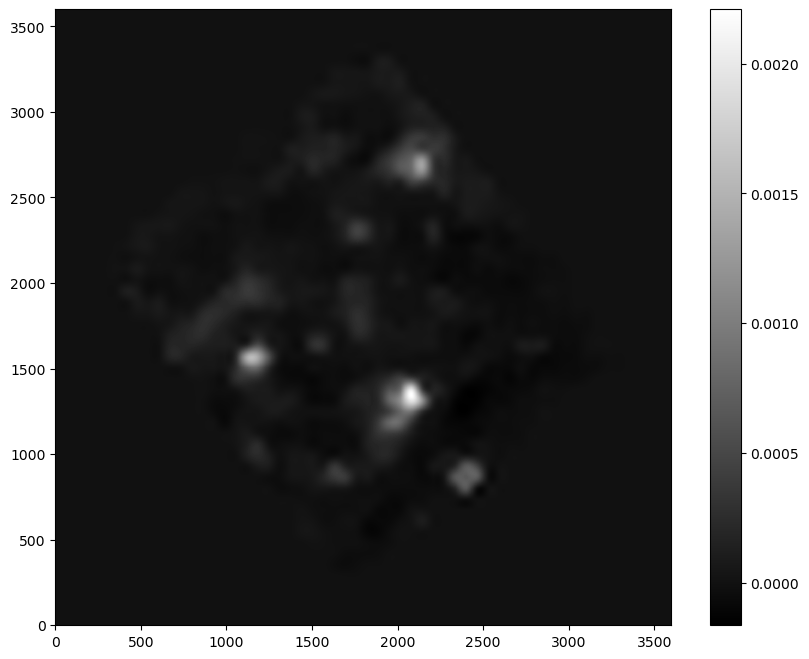

```python
plt.imshow(bkg_image, interpolation='nearest', cmap='gray', origin='lower')
plt.colorbar();
```

# evaluate the background noise as 2-d array, same size as original image

```python
bkg_rms = bkg.rms()
```

# evaluate the background noise as 2-d array, same size as original image

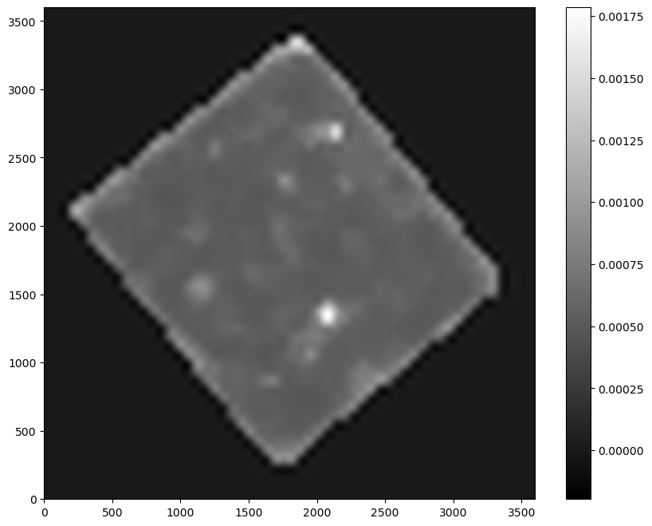

```python
plt.imshow(bkg_rms, interpolation='nearest', cmap='gray', origin='lower')
plt.colorbar();
```

# subtract the background

```python
data_sub = data - bkg
```

```python
objects = sep.extract(data_sub, 1.5, err=bkg.globalrms)
```

```python
len(objects)
```

```
8640
```

# plot background-subtracted image and plot an ellipse for each object

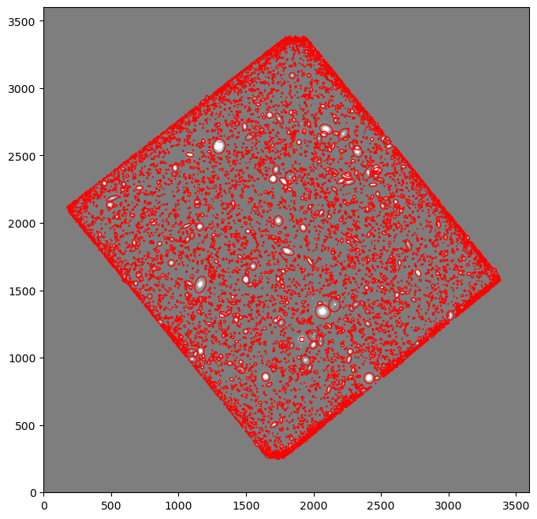

```python
from matplotlib.patches import Ellipse

# plot background-subtracted image
fig, ax = plt.subplots()
m, s = np.mean(data_sub), np.std(data_sub)
im = ax.imshow(data_sub, interpolation='nearest', cmap='gray',
               vmin=m-s, vmax=m+s, origin='lower')


for i in range(len(objects)):
    e = Ellipse(xy=(objects['x'][i], objects['y'][i]),
                width=6*objects['a'][i],
                height=6*objects['b'][i],
                angle=objects['theta'][i] * 180. / np.pi)
    e.set_facecolor('none')
    e.set_edgecolor('red')
    ax.add_artist(e)
```

Availible fields

```python
objects.dtype.names
```

```
('thresh',
 'npix',
 'tnpix',
 'xmin',
 'xmax',
 'ymin',
 'ymax',
 'x',
 'y',
 'x2',
 'y2',
 'xy',
 'errx2',
 'erry2',
 'errxy',
 'a',
 'b',
 'theta',
 'cxx',
 'cyy',
 'cxy',
 'cflux',
 'flux',
 'cpeak',
 'peak',
 'xcpeak',
 'ycpeak',
 'xpeak',
 'ypeak',
 'flag')
```

```python
flux, fluxerr, flag = sep.sum_circle(data_sub, objects['x'], objects['y'],
                                     3.0, err=bkg.globalrms, gain=1.0)
```

show the first 10 objects results:

```python
for i in range(10):
    print("object {:d}: flux = {:f} +/- {:f}".format(i, flux[i], fluxerr[i]))
```

```
object 0: flux = 0.031282 +/- 0.176890
object 1: flux = 0.031018 +/- 0.176142
object 2: flux = -0.024388 +/- 0.002883
object 3: flux = 0.001947 +/- 0.044219
object 4: flux = 0.012457 +/- 0.111649
object 5: flux = -0.011228 +/- 0.002875
object 6: flux = 0.029368 +/- 0.171394
object 7: flux = -0.009126 +/- 0.002875
object 8: flux = 0.048023 +/- 0.219161
object 9: flux = 0.027840 +/- 0.166877
```

[figure not shown]

```python
x = ("object {:d}: flux = {:f} +/- {:f}".format(i, flux[i], fluxerr[i]),0,9,10)
y = ("object {:d}: flux = {:f} +/- {:f}".format(i, flux[i], fluxerr[i]))
bins = 10
plt.hist(x, bins = bins)
plt.xlabel('stars')
plt.ylabel('fluxes')
```